# Análisis Exploratorio de los Datos DETECCIÓN CÁNCER DE MAMA , CERVIX UTERINO Y VACUNACIÓN

Alicia Perdices Guerra

20 de mayo, 2021

- **1.ANÁLISIS EXPLORATORIO POR PAISES.**
  - 1.1 EN RELACIÓN CON PREVENCION
    - 1.1.1 Análisis Descriptivo
    - 1.1.2 Visualización y Distribución de la variable “Value”
      - DETECCIÓN DE CÁNCER DE MAMA Y CERVIX UTERINO.
      - VACUNACIÓN A LA POBLACIÓN MAYORES DE 65 AÑOS.
    - 1.1.3 Normalidad de la variable “Value”
      - DETECCIÓN DE CÁNCER DE MAMA Y CERVIX UTERINO.
      - VACUNACIÓN A LA POBLACIÓN MAYORES DE 65 AÑOS.

#### **1.ANÁLISIS EXPLORATORIO POR PAISES**

Se procede en primer lugar a cargar todos los archivos para poder realizar el análisis.

```r
deteccion_cu<-read.csv("C:/temp/Deteccion_Cancer_Mama_Cervix_clean.csv",sep= ",")
vacunacion<-read.csv("C:/temp/Vacunacion_+65_clean.csv",sep= ",")
```

**1.1.- EN RELACIÓN CON LA PREVENCIÓN SANITARIA**

- **1.1.1 Análisis Descriptivo**

Se procede a realizar el análisis descriptivo:

```r
summary(deteccion_cu)
```

```
##       TIME          GEO                UNIT              SOURCE
##  Min.   :2010   Length:1440        Length:1440        Length:1440
##  1st Qu.:2012   Class :character   Class :character   Class :character
##  Median :2014   Mode  :character   Mode  :character   Mode  :character
##  Mean   :2014
##  3rd Qu.:2017
##  Max.   :2019
##     ICD10               Value       Value_imp
##  Length:1440        Min.   : 0.04   Mode :logical
##  Class :character   1st Qu.:53.65   FALSE:525
##  Mode  :character   Median :67.70   TRUE :915
##                     Mean   :60.79
##                     3rd Qu.:73.59
##                     Max.   :90.40
```

```r
summary(vacunacion)
```

```
##       TIME          GEO                UNIT               Value
##  Min.   :2010   Length:380         Length:380         Min.   : 0.90
##  1st Qu.:2012   Class :character   Class :character   1st Qu.:15.55
##  Median :2014   Mode  :character   Mode  :character   Median :40.04
##  Mean   :2014                                         Mean   :35.50
##  3rd Qu.:2017                                         3rd Qu.:50.00
##  Max.   :2019                                         Max.   :74.00
##  Value_imp
##  Mode :logical
##  FALSE:261
##  TRUE :119
##
##
##
```

Se filta el dataframe para que la variable GEO aparezcan solo los paises objeto de estudio.(Para cada archivo relacionado con La Prevención y unificamos la información ). Además se selecciona la información relevante de las variables ICD10 (tipo de cáncer), SOURCE (Survey Data)

```r
#En relación con la Prevención
#==============================


#Detección del Cáncer de Mama
#=============================
# Se selecciona la fuente: SOURCE="Survey data"
deteccion_cu<-filter(deteccion_cu,SOURCE=="Survey data")

#Se filtra por tipo de cancer: Cáncer de mama: "Malignant neoplasm of breast"
deteccion_cmama<-filter(deteccion_cu,ICD10=="Malignant neoplasm of breast")
nrow(deteccion_cmama)
```

```
## [1] 360
```

```r
head(deteccion_cmama$Value)
```

```
## [1] 67.3 70.0 75.4 75.4 71.3 62.0
```

```r
#Detección del Cáncer de Cérvix Uterino.
#======================================

#Se filtra por tipo de cancer: Cáncer de Cérvix Uterino: "Malignant neoplasm of breast"
deteccion_ccu<-filter(deteccion_cu,ICD10=="Malignant neoplasm of cervix uteri")
nrow(deteccion_ccu)
```

```
## [1] 360
```

```r
#Vacunación a mayores de 65 años.
#=================================

vacunacion<- filter(vacunacion,
              +(GEO!="European Union - 27 countries (from 2020)")&
             +(GEO!="European Union - 28 countries (2013-2020)"))
nrow(vacunacion)
```

```
## [1] 360
```

Se crea un Dataframe con toda la información:

```r
year<-(vacunacion$TIME)#Columna Year
country<-(vacunacion$GEO)#Columna Paises


#Dataframe con toda la información relacionada
#con la prevención:cáncer de mama y cérvix uterino, y vacunación
prevencion<-data.frame("TIME"=year,"Pais"=country,
                     "Deteccion_cancer_mama"=
                       deteccion_cmama$Value,
                     "Deteccion_cancer_cervix_uterino"=
                       deteccion_ccu$Value,
                     "Vacunacion"=
                       vacunacion$Value)

max(prevencion$Deteccion_cancer_mama)
```

```
## [1] 90.4
```

```r
max(prevencion$Deteccion_cancer_cervix_uterino)
```

```
## [1] 87.2
```

```r
max(prevencion$Vacunacion)
```

```
## [1] 74
```

```r
#Generamos el fichero filtrado para utilizarlo en el siguiente análisis.
write.csv(prevencion, file="Prevencion_Analisis.csv", row.names = FALSE)
```

Se reescalan los datos:

```r
prevencion["Deteccion_cancer_mama_norm"]<-
  rescale(prevencion$Deteccion_cancer_mama, to=c(0,1))
prevencion["Deteccion_cancer_cervix_uterino_norm"]<-
  rescale(prevencion$Deteccion_cancer_cervix_uterino, to=c(0,1))
prevencion["Vacunacion_norm"]<-
  rescale(prevencion$Vacunacion, to=c(0,1))
```

- **1.1.2 Visualización y Distribución de la información"**

Se visualiza las variable que nos dan información sobre la prevención realizada en función de TIME, y País.

```r
#Prevención_GRÁFICAS DE BARRAS
#=============================================================================
#Gráfica de barras de la información sobre la Detección del Cáncer de Mama"
plot1=ggplot(data=prevencion)+
  geom_col(aes(x=TIME,y=Deteccion_cancer_mama))+
  theme(axis.text.x = element_text(angle = 45))+
  scale_y_continuous(limit=c(0,100))+
  ggtitle("% Deteccion \n Cáncer Mama")+
  theme (plot.title = element_text(size=rel(0.5), hjust = 0.5))

#Gráfica de barras de la información sobre la Detección del Cáncer de Cérvix Uterino"
plot2=ggplot(data=prevencion)+
  geom_col(aes(x=TIME,y=Deteccion_cancer_cervix_uterino))+
  theme(axis.text.x = element_text(size= 5,angle = 30,vjust=1,hjust = 1))+
  scale_y_continuous(limit=c(0,100))+
  ggtitle("% Deteccion \n Cáncer Cérvix Uterino")+
  theme (plot.title = element_text(size=rel(0.5),hjust = 0.5))

#Gráfica de barras del porcentaje de Vacunados (>65)"
plot3=ggplot(data=prevencion)+
  geom_col(aes(x=TIME,y=Vacunacion))+
  theme(axis.text.x = element_text(size= 5,angle = 30,vjust=1,hjust = 1))+
  scale_y_continuous(limit=c(0,100))+
  ggtitle("% Vacunación+65")+
  theme (plot.title = element_text(size=rel(0.5),hjust = 0.5))
```

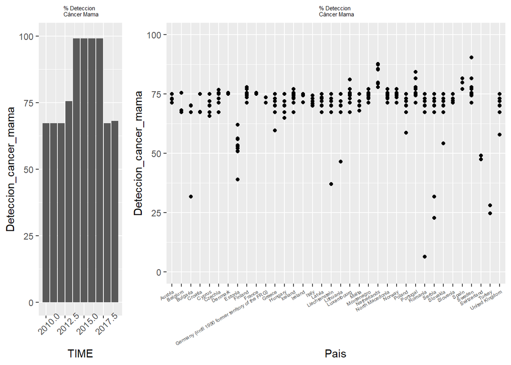

```r
#Prevención_GRÁFICAS DE PUNTOS
#=============================================================================
#Gráfica de puntos de la información sobre la Detección del Cáncer de Mama por Países"
plot4=ggplot(data=prevencion)+
  geom_point(aes(x=Pais,y=Deteccion_cancer_mama))+
  theme(axis.text.x = element_text(size= 5,angle = 30,vjust=1,hjust = 1))+
  scale_y_continuous(limit=c(0,100))+
  ggtitle("% Deteccion \n Cáncer Mama")+
  theme (plot.title = element_text(size=rel(0.5),hjust=0.5))

#Gráfica de puntos de la información sobre la Detección del Cáncer de Cérvix Uterino por Países"
plot5=ggplot(data=prevencion)+
  geom_point(aes(x=Pais,y=Deteccion_cancer_cervix_uterino))+
  theme(axis.text.x = element_text(size= 5,angle = 30,vjust=1,hjust = 1))+
  scale_y_continuous(limit=c(0,100))+
  ggtitle("% Deteccion \n Cáncer Cérvix Uterino")+
  theme (plot.title = element_text(size=rel(0.5),hjust=0.5))

#Gráfica de puntos del porcentaje de Vacunados (>65) por Países
plot6=ggplot(data=prevencion)+
  geom_point(aes(x=Pais,y=Vacunacion))+
  theme(axis.text.x = element_text(size= 5,angle = 30,vjust=1,hjust = 1))+
  scale_y_continuous(limit=c(0,100))+
  ggtitle("% Vacunación+65")+
  theme (plot.title = element_text(size=rel(0.5),hjust=0.5))

grid.arrange(plot1,plot4,widths=c(1,3),  ncol=2)
```

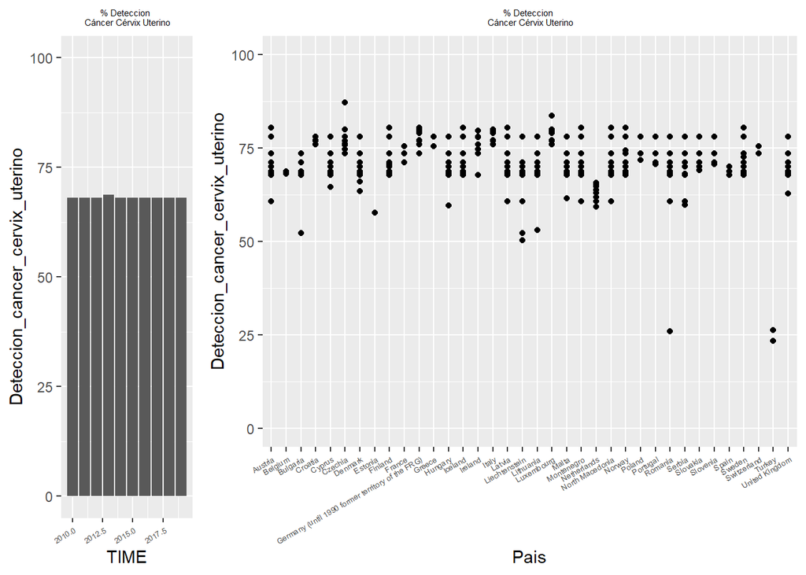

```r
grid.arrange(plot2,plot5,widths=c(1,3), ncol=2)
```

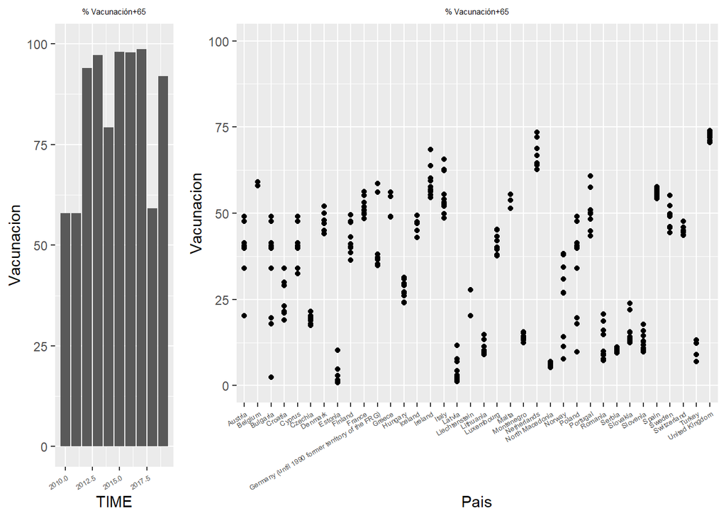

```r
grid.arrange(plot3,plot6,widths=c(1,3), ncol=2)
```

Se obtienen los 5 países con mayor porcentaje en Detección de Cáncer de Mama, Cérvix Uterino y población vacunada mayor de 65 años:

- **Deteccion_cancer_mama**

```r
#########################################
#Para "Deteccion_cancer_mama"#
#########################################

#Se filtra por Año
y_2010<-filter(prevencion, TIME==2010)
y_2011<-filter(prevencion, TIME==2011)
y_2012<-filter(prevencion, TIME==2012)
y_2013<-filter(prevencion, TIME==2013)
y_2014<-filter(prevencion, TIME==2014)
y_2015<-filter(prevencion, TIME==2015)
y_2016<-filter(prevencion, TIME==2016)
y_2017<-filter(prevencion, TIME==2017)
y_2018<-filter(prevencion, TIME==2018)
y_2019<-filter(prevencion, TIME==2019)

#Se ordena por "Deteccion_cancer_mama"

prevencion_5paises_2010<-y_2010[with(y_2010, order(-y_2010$Deteccion_cancer_mama)),]
prevencion_5paises_2011<-y_2011[with(y_2011, order(-y_2011$Deteccion_cancer_mama)),]
prevencion_5paises_2012<-y_2012[with(y_2012, order(-y_2012$Deteccion_cancer_mama)),]
prevencion_5paises_2013<-y_2013[with(y_2013, order(-y_2013$Deteccion_cancer_mama)),]
prevencion_5paises_2014<-y_2014[with(y_2014, order(-y_2014$Deteccion_cancer_mama)),]
prevencion_5paises_2015<-y_2015[with(y_2015, order(-y_2015$Deteccion_cancer_mama)),]
prevencion_5paises_2016<-y_2016[with(y_2016, order(-y_2016$Deteccion_cancer_mama)),]
prevencion_5paises_2017<-y_2017[with(y_2017, order(-y_2017$Deteccion_cancer_mama)),]
prevencion_5paises_2018<-y_2018[with(y_2018, order(-y_2018$Deteccion_cancer_mama)),]
prevencion_5paises_2019<-y_2019[with(y_2019, order(-y_2019$Deteccion_cancer_mama)),]


#Se crea una tabla para cada año sobre la Detección del Cáncer de Mama
#de los 5 Paises con un valor más alto.

kable(prevencion_5paises_2010[0:5,c(2,3)], col.names = c("País","% CMama"),
      caption = "Países con mayor % en Detección de Cáncer de Mama en 2010")
```

Países con mayor % en Detección de Cáncer de Mama en 2010

|  | País | % CMama |
| --- | --- | --- |
| 19 | Netherlands | 87.6 |
| 9 | Spain | 79.8 |
| 3 | Czechia | 75.4 |
| 4 | Denmark | 75.4 |
| 10 | France | 75.4 |

```r
kable(prevencion_5paises_2011[0:5,c(2,3)], col.names = c("País","% CMama"),
      caption = "Países con mayor % en Detección de Cáncer de Mama en 2011")
```

Países con mayor % en Detección de Cáncer de Mama en 2011

|  | País | % CMama |
| --- | --- | --- |
| 19 | Netherlands | 85.6 |
| 9 | Spain | 77.1 |
| 16 | Luxembourg | 77.1 |
| 22 | Portugal | 77.1 |
| 26 | Finland | 77.1 |

```r
kable(prevencion_5paises_2012[0:5,c(2,3)], col.names = c("País","% CMama"),
      caption = "Países con mayor % en Detección de Cáncer de Mama en 2012")
```

Países con mayor % en Detección de Cáncer de Mama en 2012

|  | País | % CMama |
| --- | --- | --- |
| 19 | Netherlands | 87.3 |
| 9 | Spain | 79.8 |
| 4 | Denmark | 75.0 |
| 10 | France | 75.0 |
| 7 | Ireland | 71.4 |

```r
kable(prevencion_5paises_2013[0:5,c(2,3)], col.names = c("País","% CMama"),
      caption = "Países con mayor % en Detección de Cáncer de Mama en 2013")
```

Países con mayor % en Detección de Cáncer de Mama en 2013

|  | País | % CMama |
| --- | --- | --- |
| 19 | Netherlands | 85.3 |
| 9 | Spain | 79.8 |
| 1 | Belgium | 75.5 |
| 3 | Czechia | 75.5 |
| 16 | Luxembourg | 75.5 |

```r
kable(prevencion_5paises_2014[0:5,c(2,3)], col.names = c("País","% CMama"),
      caption = "Países con mayor % en Detección de Cáncer de Mama en 2014")
```

Países con mayor % en Detección de Cáncer de Mama en 2014

|  | País | % CMama |
| --- | --- | --- |
| 27 | Sweden | 90.40 |
| 22 | Portugal | 84.20 |
| 16 | Luxembourg | 81.02 |
| 9 | Spain | 79.80 |
| 19 | Netherlands | 79.80 |

```r
kable(prevencion_5paises_2015[0:5,c(2,3)], col.names = c("País","% CMama"),
      caption = "Países con mayor % en Detección de Cáncer de Mama en 2015")
```

Países con mayor % en Detección de Cáncer de Mama en 2015

|  | País | % CMama |
| --- | --- | --- |
| 9 | Spain | 79.8 |
| 19 | Netherlands | 79.6 |
| 10 | France | 75.0 |
| 3 | Czechia | 74.9 |
| 4 | Denmark | 74.9 |

```r
kable(prevencion_5paises_2016[0:5,c(2,3)], col.names = c("País","% CMama"),
      caption = "Países con mayor % en Detección de Cáncer de Mama en 2016")
```

Países con mayor % en Detección de Cáncer de Mama en 2016

|  | País | % CMama |
| --- | --- | --- |
| 9 | Spain | 79.8 |
| 19 | Netherlands | 77.9 |
| 22 | Portugal | 77.9 |
| 26 | Finland | 77.9 |
| 27 | Sweden | 77.9 |

```r
kable(prevencion_5paises_2017[0:5,c(2,3)], col.names = c("País","% CMama"),
      caption = "Países con mayor % en Detección de Cáncer de Mama en 2017")
```

Países con mayor % en Detección de Cáncer de Mama en 2017

|  | País | % CMama |
| --- | --- | --- |
| 9 | Spain | 81.48 |
| 22 | Portugal | 81.48 |
| 27 | Sweden | 81.48 |
| 16 | Luxembourg | 81.02 |
| 19 | Netherlands | 79.30 |

```r
kable(prevencion_5paises_2018[0:5,c(2,3)], col.names = c("País","% CMama"),
      caption = "Países con mayor % en Detección de Cáncer de Mama en 2018")
```

Países con mayor % en Detección de Cáncer de Mama en 2018

|  | País | % CMama |
| --- | --- | --- |
| 9 | Spain | 79.8 |
| 19 | Netherlands | 79.8 |
| 4 | Denmark | 75.0 |
| 10 | France | 75.0 |
| 7 | Ireland | 74.3 |

```r
kable(prevencion_5paises_2019[0:5,c(2,3)], col.names = c("País","% CMama"),
      caption = "Países con mayor % en Detección de Cáncer de Mama en 2019")
```

Países con mayor % en Detección de Cáncer de Mama en 2019

|  | País | % CMama |
| --- | --- | --- |
| 9 | Spain | 79.8 |
| 19 | Netherlands | 79.3 |
| 4 | Denmark | 75.0 |
| 10 | France | 75.0 |
| 7 | Ireland | 74.3 |

A continuación, se aprupa toda la información por paises en una tabla:

```r
a1<-group_by(prevencion,Pais)#Se agrupa por paises
#Se selecciona las variables Pais y Deteccion_cancer_mama
a2<-select(a1,Pais:Deteccion_cancer_mama)
#Se muestra la información por cada país, con Value=suma de
#los valores de cada país en los 10 años.
a3<-(summarize(a2,suma=sum(Deteccion_cancer_mama)/10))
a4<-data.frame(a3)#Se convierte la información en un dataframe.
#Se ordena el DataFrame por la variable Suma de forma descendente.
a5<-a4[with(a4,order(-a4$suma)),]

#Se crea una tabla con toda la informacion
kable(a5[0:5,c(1,2)],
      col.names = c("País","% C.Mama"),
      caption = "Países con la mayor media en Detección de Cáncer de Mama en 2010-2019")
```

Países con la mayor media en Detección de Cáncer de Mama en 2010-2019

|  | País | % C.Mama |
| --- | --- | --- |
| 23 | Netherlands | 82.150 |
| 32 | Spain | 79.698 |
| 33 | Sweden | 77.258 |
| 27 | Portugal | 76.638 |
| 10 | France | 75.120 |

- **Deteccion_cancer_cervix_uterino**

```r
#########################################
#Para "Deteccion_cancer_cervix_uterino"#
#########################################

#Se ordena por "Deteccion_cancer_cervix_uterino"

prevencion_5paises_2010<-y_2010[with(y_2010, order(-y_2010$Deteccion_cancer_cervix_uterino)),]
prevencion_5paises_2011<-y_2011[with(y_2011, order(-y_2011$Deteccion_cancer_cervix_uterino)),]
prevencion_5paises_2012<-y_2012[with(y_2012, order(-y_2012$Deteccion_cancer_cervix_uterino)),]
prevencion_5paises_2013<-y_2013[with(y_2013, order(-y_2013$Deteccion_cancer_cervix_uterino)),]
prevencion_5paises_2014<-y_2014[with(y_2014, order(-y_2014$Deteccion_cancer_cervix_uterino)),]
prevencion_5paises_2015<-y_2015[with(y_2015, order(-y_2015$Deteccion_cancer_cervix_uterino)),]
prevencion_5paises_2016<-y_2016[with(y_2016, order(-y_2016$Deteccion_cancer_cervix_uterino)),]
prevencion_5paises_2017<-y_2017[with(y_2017, order(-y_2017$Deteccion_cancer_cervix_uterino)),]
prevencion_5paises_2018<-y_2018[with(y_2018, order(-y_2018$Deteccion_cancer_cervix_uterino)),]
prevencion_5paises_2019<-y_2019[with(y_2019, order(-y_2019$Deteccion_cancer_cervix_uterino)),]


#Se crea una tabla para cada año sobre la Detección del Cáncer de Cérvix Uterino
#de los 5 Paises con un valor más alto.

kable(prevencion_5paises_2010[0:5,c(2,3)], col.names = c("País","% C Cérvix"),
      caption = "Países con mayor % en Detección de Cáncer de Cérvix en 2010")
```

Países con mayor % en Detección de Cáncer de Cérvix en 2010

|  | País | % C Cérvix |
| --- | --- | --- |
| 3 | Czechia | 75.4 |
| 5 | Germany (until 1990 former territory of the FRG) | 71.3 |
| 7 | Ireland | 74.9 |
| 11 | Croatia | 67.4 |
| 12 | Italy | 70.0 |

```r
kable(prevencion_5paises_2011[0:5,c(2,3)], col.names = c("País","% C Cérvix"),
      caption = "Países con mayor % en Detección de Cáncer de Cérvix en 2011")
```

Países con mayor % en Detección de Cáncer de Cérvix en 2011

|  | País | % C Cérvix |
| --- | --- | --- |
| 3 | Czechia | 76.7 |
| 5 | Germany (until 1990 former territory of the FRG) | 71.3 |
| 11 | Croatia | 67.4 |
| 12 | Italy | 70.1 |
| 16 | Luxembourg | 77.1 |

```r
kable(prevencion_5paises_2012[0:5,c(2,3)], col.names = c("País","% C Cérvix"),
      caption = "Países con mayor % en Detección de Cáncer de Cérvix en 2012")
```

Países con mayor % en Detección de Cáncer de Cérvix en 2012

|  | País | % C Cérvix |
| --- | --- | --- |
| 11 | Croatia | 67.4 |
| 12 | Italy | 70.0 |
| 16 | Luxembourg | 71.3 |
| 8 | Greece | 70.0 |
| 31 | Switzerland | 47.4 |

```r
kable(prevencion_5paises_2013[0:5,c(2,3)], col.names = c("País","% C Cérvix"),
      caption = "Países con mayor % en Detección de Cáncer de Cérvix en 2013")
```

Países con mayor % en Detección de Cáncer de Cérvix en 2013

|  | País | % C Cérvix |
| --- | --- | --- |
| 5 | Germany (until 1990 former territory of the FRG) | 73.5 |
| 11 | Croatia | 67.4 |
| 12 | Italy | 70.2 |
| 16 | Luxembourg | 75.5 |
| 8 | Greece | 70.2 |

```r
kable(prevencion_5paises_2014[0:5,c(2,3)], col.names = c("País","% C Cérvix"),
      caption = "Países con mayor % en Detección de Cáncer de Cérvix en 2014")
```

Países con mayor % en Detección de Cáncer de Cérvix en 2014

|  | País | % C Cérvix |
| --- | --- | --- |
| 3 | Czechia | 76.70 |
| 16 | Luxembourg | 81.02 |
| 5 | Germany (until 1990 former territory of the FRG) | 73.50 |
| 14 | Latvia | 73.50 |
| 20 | Austria | 72.70 |

```r
kable(prevencion_5paises_2015[0:5,c(2,3)], col.names = c("País","% C Cérvix"),
      caption = "Países con mayor % en Detección de Cáncer de Cérvix en 2015")
```

Países con mayor % en Detección de Cáncer de Cérvix en 2015

|  | País | % C Cérvix |
| --- | --- | --- |
| 5 | Germany (until 1990 former territory of the FRG) | 71.3 |
| 12 | Italy | 72.0 |
| 16 | Luxembourg | 74.9 |
| 3 | Czechia | 74.9 |
| 4 | Denmark | 74.9 |

```r
kable(prevencion_5paises_2016[0:5,c(2,3)], col.names = c("País","% C Cérvix"),
      caption = "Países con mayor % en Detección de Cáncer de Cérvix en 2016")
```

Países con mayor % en Detección de Cáncer de Cérvix en 2016

|  | País | % C Cérvix |
| --- | --- | --- |
| 3 | Czechia | 73.0 |
| 5 | Germany (until 1990 former territory of the FRG) | 71.3 |
| 12 | Italy | 73.0 |
| 16 | Luxembourg | 73.0 |
| 7 | Ireland | 74.9 |

```r
kable(prevencion_5paises_2017[0:5,c(2,3)], col.names = c("País","% C Cérvix"),
      caption = "Países con mayor % en Detección de Cáncer de Cérvix en 2017")
```

Países con mayor % en Detección de Cáncer de Cérvix en 2017

|  | País | % C Cérvix |
| --- | --- | --- |
| 5 | Germany (until 1990 former territory of the FRG) | 73.50 |
| 12 | Italy | 73.00 |
| 16 | Luxembourg | 81.02 |
| 7 | Ireland | 74.90 |
| 11 | Croatia | 75.00 |

```r
kable(prevencion_5paises_2018[0:5,c(2,3)], col.names = c("País","% C Cérvix"),
      caption = "Países con mayor % en Detección de Cáncer de Cérvix en 2018")
```

Países con mayor % en Detección de Cáncer de Cérvix en 2018

|  | País | % C Cérvix |
| --- | --- | --- |
| 5 | Germany (until 1990 former territory of the FRG) | 71.3 |
| 12 | Italy | 74.3 |
| 16 | Luxembourg | 74.3 |
| 7 | Ireland | 74.3 |
| 11 | Croatia | 67.3 |

```r
kable(prevencion_5paises_2019[0:5,c(2,3)], col.names = c("País","% C Cérvix"),
      caption = "Países con mayor % en Detección de Cáncer de Cérvix en 2019")
```

Países con mayor % en Detección de Cáncer de Cérvix en 2019

|  | País | % C Cérvix |
| --- | --- | --- |
| 5 | Germany (until 1990 former territory of the FRG) | 71.3 |
| 12 | Italy | 73.0 |
| 16 | Luxembourg | 67.3 |
| 7 | Ireland | 74.3 |
| 11 | Croatia | 67.3 |

A continuación, se aprupa toda la información por paises en una tabla:

```r
a1<-group_by(prevencion,Pais)#Se agrupa por paises
#Se selecciona las variables Pais y Deteccion_cancer_cervix_uterino
a2<-select(a1,Pais:Deteccion_cancer_cervix_uterino)
#Se muestra la información por cada país, con Value=suma de
#los valores de cada país en los 10 años.
a3<-(summarize(a2,suma=sum(Deteccion_cancer_cervix_uterino)/10))
a4<-data.frame(a3)#Se convierte la información en un dataframe.
#Se ordena el DataFrame por la variable Suma de forma descendente.
a5<-a4[with(a4,order(-a4$suma)),]

#Se crea una tabla con toda la informacion
kable(a5[0:5,c(1,2)],
      col.names = c("País","% C Cérvix"),
      caption = "Países con la mayor media en Detección de Cáncer de Cérvix en 2010-2019")
```

Países con la mayor media en Detección de Cáncer de Cérvix en 2010-2019

|  | País | % C Cérvix |
| --- | --- | --- |
| 20 | Luxembourg | 78.790 |
| 16 | Italy | 78.330 |
| 11 | Germany (until 1990 former territory of the FRG) | 78.129 |
| 6 | Czechia | 77.401 |
| 4 | Croatia | 77.042 |

- **Vacunacion**

```r
#########################################
#Para "VAcunacion"#
#########################################

#Se ordena por "Vacunacion"

prevencion_5paises_2010<-y_2010[with(y_2010, order(-y_2010$Vacunacion)),]
prevencion_5paises_2011<-y_2011[with(y_2011, order(-y_2011$Vacunacion)),]
prevencion_5paises_2012<-y_2012[with(y_2012, order(-y_2012$Vacunacion)),]
prevencion_5paises_2013<-y_2013[with(y_2013, order(-y_2013$Vacunacion)),]
prevencion_5paises_2014<-y_2014[with(y_2014, order(-y_2014$Vacunacion)),]
prevencion_5paises_2015<-y_2015[with(y_2015, order(-y_2015$Vacunacion)),]
prevencion_5paises_2016<-y_2016[with(y_2016, order(-y_2016$Vacunacion)),]
prevencion_5paises_2017<-y_2017[with(y_2017, order(-y_2017$Vacunacion)),]
prevencion_5paises_2018<-y_2018[with(y_2018, order(-y_2018$Vacunacion)),]
prevencion_5paises_2019<-y_2019[with(y_2019, order(-y_2019$Vacunacion)),]


#Se crea una tabla para cada año sobre la Vacunación a mayores de 65 años
#de los 5 Paises con un valor más alto.

kable(prevencion_5paises_2010[0:5,c(2,3)], col.names = c("País","% Vacunacion"),
      caption = "Países con mayor % Vacunación a mayores de 65 años en 2010")
```

Países con mayor % Vacunación a mayores de 65 años en 2010

|  | País | % Vacunacion |
| --- | --- | --- |
| 32 | United Kingdom | 70.0 |
| 19 | Netherlands | 87.6 |
| 12 | Italy | 70.0 |
| 7 | Ireland | 74.9 |
| 1 | Belgium | 67.3 |

```r
kable(prevencion_5paises_2011[0:5,c(2,3)], col.names = c("País","% Vacunacion"),
      caption = "Países con mayor % Vacunación a mayores de 65 años en 2011")
```

Países con mayor % Vacunación a mayores de 65 años en 2011

|  | País | % Vacunacion |
| --- | --- | --- |
| 32 | United Kingdom | 70.1 |
| 19 | Netherlands | 85.6 |
| 12 | Italy | 70.1 |
| 1 | Belgium | 67.3 |
| 9 | Spain | 77.1 |

```r
kable(prevencion_5paises_2012[0:5,c(2,3)], col.names = c("País","% Vacunacion"),
      caption = "Países con mayor % Vacunación a mayores de 65 años en 2012")
```

Países con mayor % Vacunación a mayores de 65 años en 2012

|  | País | % Vacunacion |
| --- | --- | --- |
| 19 | Netherlands | 87.3 |
| 32 | United Kingdom | 70.0 |
| 12 | Italy | 70.0 |
| 5 | Germany (until 1990 former territory of the FRG) | 71.3 |
| 1 | Belgium | 67.3 |

```r
kable(prevencion_5paises_2013[0:5,c(2,3)], col.names = c("País","% Vacunacion"),
      caption = "Países con mayor % Vacunación a mayores de 65 años en 2013")
```

Países con mayor % Vacunación a mayores de 65 años en 2013

|  | País | % Vacunacion |
| --- | --- | --- |
| 32 | United Kingdom | 70.2 |
| 19 | Netherlands | 85.3 |
| 7 | Ireland | 74.9 |
| 1 | Belgium | 75.5 |
| 9 | Spain | 79.8 |

```r
kable(prevencion_5paises_2014[0:5,c(2,3)], col.names = c("País","% Vacunacion"),
      caption = "Países con mayor % Vacunación a mayores de 65 años en 2014")
```

Países con mayor % Vacunación a mayores de 65 años en 2014

|  | País | % Vacunacion |
| --- | --- | --- |
| 32 | United Kingdom | 57.9 |
| 19 | Netherlands | 79.8 |
| 7 | Ireland | 74.9 |
| 1 | Belgium | 67.3 |
| 9 | Spain | 79.8 |

```r
kable(prevencion_5paises_2015[0:5,c(2,3)], col.names = c("País","% Vacunacion"),
      caption = "Países con mayor % Vacunación a mayores de 65 años en 2015")
```

Países con mayor % Vacunación a mayores de 65 años en 2015

|  | País | % Vacunacion |
| --- | --- | --- |
| 32 | United Kingdom | 72.0 |
| 19 | Netherlands | 79.6 |
| 1 | Belgium | 67.3 |
| 9 | Spain | 79.8 |
| 7 | Ireland | 74.9 |

```r
kable(prevencion_5paises_2016[0:5,c(2,3)], col.names = c("País","% Vacunacion"),
      caption = "Países con mayor % Vacunación a mayores de 65 años en 2016")
```

Países con mayor % Vacunación a mayores de 65 años en 2016

|  | País | % Vacunacion |
| --- | --- | --- |
| 32 | United Kingdom | 73.0 |
| 19 | Netherlands | 77.9 |
| 1 | Belgium | 67.3 |
| 22 | Portugal | 77.9 |
| 9 | Spain | 79.8 |

```r
kable(prevencion_5paises_2017[0:5,c(2,3)], col.names = c("País","% Vacunacion"),
      caption = "Países con mayor % Vacunación a mayores de 65 años en 2017")
```

Países con mayor % Vacunación a mayores de 65 años en 2017

|  | País | % Vacunacion |
| --- | --- | --- |
| 32 | United Kingdom | 75.00 |
| 19 | Netherlands | 79.30 |
| 22 | Portugal | 81.48 |
| 1 | Belgium | 67.30 |
| 7 | Ireland | 74.90 |

```r
kable(prevencion_5paises_2018[0:5,c(2,3)], col.names = c("País","% Vacunacion"),
      caption = "Países con mayor % Vacunación a mayores de 65 años en 2018")
```

Países con mayor % Vacunación a mayores de 65 años en 2018

|  | País | % Vacunacion |
| --- | --- | --- |
| 32 | United Kingdom | 67.3 |
| 7 | Ireland | 74.3 |
| 19 | Netherlands | 79.8 |
| 1 | Belgium | 67.3 |
| 22 | Portugal | 74.3 |

```r
kable(prevencion_5paises_2019[0:5,c(2,3)], col.names = c("País","% Vacunacion"),
      caption = "Países con mayor % Vacunación a mayores de 65 años en 2019")
```

Países con mayor % Vacunación a mayores de 65 años en 2019

|  | País | % Vacunacion |
| --- | --- | --- |
| 32 | United Kingdom | 67.3 |
| 19 | Netherlands | 79.3 |
| 1 | Belgium | 68.1 |
| 7 | Ireland | 74.3 |
| 22 | Portugal | 74.3 |

A continuación, se aprupa toda la información por paises en una tabla:

```r
a1<-group_by(prevencion,Pais)#Se agrupa por paises
#Se selecciona las variables Pais y Vacunación
a2<-select(a1,Pais:Vacunacion)
#Se muestra la información por cada país, con Value=suma de
#los valores de cada país en los 10 años.
a3<-(summarize(a2,suma=sum(Vacunacion)/10))
a4<-data.frame(a3)#Se convierte la información en un dataframe.
#Se ordena el DataFrame por la variable Suma de forma descendente.
a5<-a4[with(a4,order(-a4$suma)),]

#Se crea una tabla con toda la informacion
kable(a5[0:5,c(1,2)],
      col.names = c("País","% Vacunacion"),
      caption = "Países con la mayor media en Vacunación a mayores de 65 años en 2010-2019")
```

Países con la mayor media en Vacunación a mayores de 65 años en 2010-2019

|  | País | % Vacunacion |
| --- | --- | --- |
| 36 | United Kingdom | 72.455 |
| 23 | Netherlands | 68.040 |
| 15 | Ireland | 59.020 |
| 2 | Belgium | 58.110 |
| 32 | Spain | 56.050 |

- **1.1.3 Normalidad de la variable “Value”**

Se comprueba con métodos visuales si la variable tiene una distribución normal.

**DETECCIÓN DE CÁNCER DE MAMA**

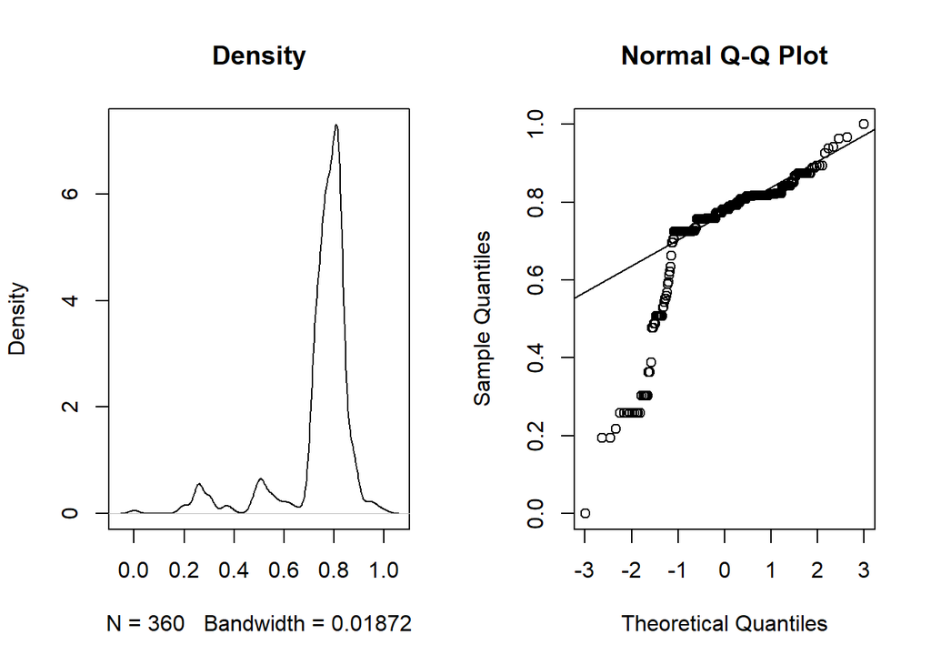

```r
par(mfrow=c(1,2))
plot(density(prevencion$Deteccion_cancer_mama_norm) ,main="Density")
qqnorm(prevencion$Deteccion_cancer_mama_norm)
qqline(prevencion$Deteccion_cancer_mama_norm)
```

Para estudiar si una muestra proviene de una población con distribución normal, se disponen de tres herramientas:

- Histograma o Densidad
- Gráficos cuantil cuantil (QQplot)
- Pruebas de hipótesis.

Si en la prueba de Densidad se observa sesgo hacia uno de los lados de la gráfica, sería indicio de que la muestra no proviene de una población normal.Si por otra parte, sí se observa simetría, **NO** se garantiza que la muestra provenga de una población normal. En estos casos sería necesario utilizar otras herramientas como **QQplot y pruebas de hipótesis**.

Por otro lado, se realizan las pruebas de hipótesis:

- $h_0: La muestra proviene de una población normal.
- $h_1: La muestra NO proviene de una población normal.

Se aplica la prueba Shapiro-Wilk:

```r
shapiro.test(prevencion$Deteccion_cancer_mama_norm)
```

```
##
##  Shapiro-Wilk normality test
##
## data:  prevencion$Deteccion_cancer_mama_norm
## W = 0.69359, p-value < 2.2e-16
```

Se observa un p-value muy pequeño, mucho más pequeño que cualquier nivel de significación ($alpha$=0.5) por lo que se rechaza la hipótesis nula y asumimos **No normalidad** en la muestra.

**DETECCIÓN DE CÁNCER DE CÉRVIX UTERINO**

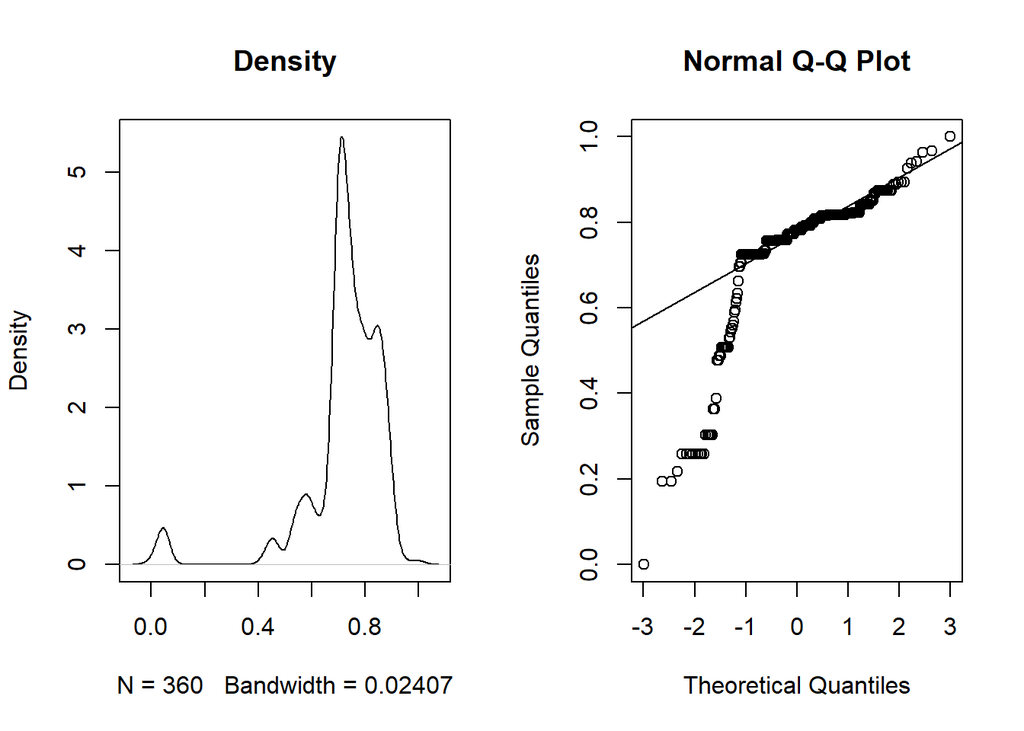

```r
par(mfrow=c(1,2))
plot(density(prevencion$Deteccion_cancer_cervix_uterino_norm) ,main="Density")
qqnorm(prevencion$Deteccion_cancer_mama_norm)
qqline(prevencion$Deteccion_cancer_mama_norm)
```

Tras aplicar la prueba Shapiro-Wilk:

```r
shapiro.test(prevencion$Deteccion_cancer_mama_norm)
```

```
##
##  Shapiro-Wilk normality test
##
## data:  prevencion$Deteccion_cancer_mama_norm
## W = 0.69359, p-value < 2.2e-16
```

Se observa un p-value muy pequeño, mucho más pequeño que cualquier nivel de significación ($alpha$=0.5) por lo que se rechaza la hipótesis nula y asumimos **No normalidad** en la muestra.

**VACUNACION A LA POBLACIÓN MAYOR DE 65 AÑOS**

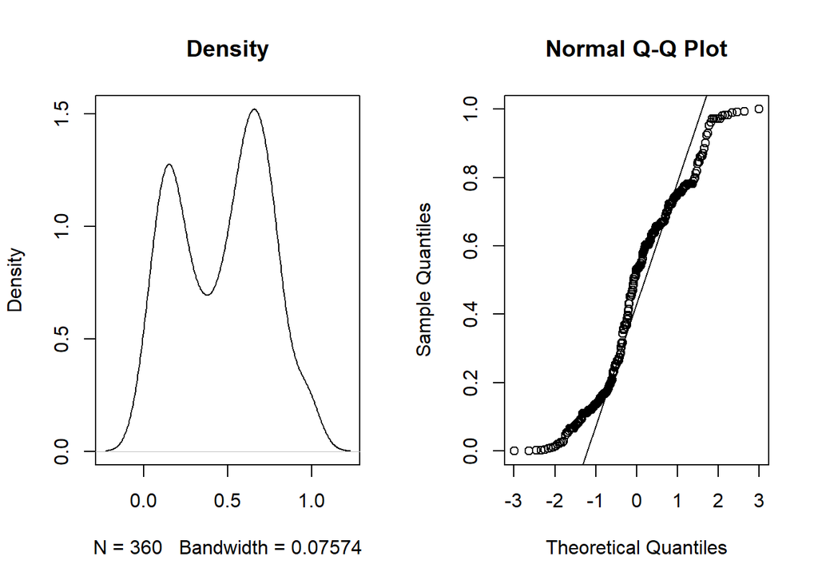

```r
par(mfrow=c(1,2))
plot(density(prevencion$Vacunacion_norm) ,main="Density")
qqnorm(prevencion$Vacunacion_norm)
qqline(prevencion$Vacunacion_norm)
```

En la gráfica Densidad de la variable “Vacunacion_norm” , se observa claramente una figura que no se aproxima a la curva de normalidad. Se puede confirmar observando la gráfica QQplot en la que la línea que grafica qqline sirve de referencia para interpretar el gráfico, no se alinea con los puntos de los valores de la variable “Vacunacion_norm”.Tan solo, existe una alineación central.

Tras aplicar la prueba Shapiro-Wilk:

```r
shapiro.test(prevencion$Vacunacion_norm)
```

```
##
##  Shapiro-Wilk normality test
##
## data:  prevencion$Vacunacion_norm
## W = 0.94426, p-value = 2.148e-10
```

Se observa un p-value muy pequeño, mucho más pequeño que cualquier nivel de significación ($alpha$=0.5) por lo que se rechaza la hipótesis nula y asumimos **No normalidad** en la muestra.